# Wide Latent Space & Embedding Models for Concentration Prediction

This notebook explores advanced Machine Learning techniques to project our 3-dimensional physical features (**Refractive Index, Conductivity, and pH**) into a **high-dimensional wide latent space**.

### Methodology: Beyond Simple Features

In complex liquid mixtures, the relationship between sensor readings and concentration is often non-linear and coupled. By creating "embeddings" or wide latent representations, we allow the model to learn complex interactions that are not captured by standard linear or polynomial models.

We evaluate two primary approaches:

1. **Kernel Approximation (Nyström Method):** Approximating an RBF kernel by projecting the data into a high-dimensional feature space.
2. **Wide Neural Network (MLP):** Using a wide hidden layer (128 units) to act as a learned embedding of the physical properties.

```python
import pandas as pd
import numpy as np
import matplotlib.pyplot as plt
import seaborn as sns
from sklearn.model_selection import train_test_split
from sklearn.preprocessing import StandardScaler
from sklearn.kernel_approximation import Nystroem
from sklearn.linear_model import Ridge
from sklearn.neural_network import MLPRegressor
from sklearn.metrics import mean_squared_error, r2_score, mean_absolute_error

# Set plot style for premium visuals
sns.set_theme(style="whitegrid")
plt.rcParams['figure.figsize'] = (14, 8)
```

## 1. Data Acquisition and Preparation

We load the `fit.csv` dataset and scale the features. Scaling is critical for neural networks and kernel methods to ensure no single feature dominates the latent space.

```python
# 1. Load Data
try:
    # Using absolute path for consistency
    df = pd.read_csv(r'c:\Users\mgpsk\Documents\voc-streamlit\fit.csv')
    print("Dataset loaded successfully.")
except FileNotFoundError:
    print(r"Error: c:\Users\mgpsk\Documents\voc-streamlit\fit.csv not found.")
    exit()

# Features and Target
X = df[['R', 'Cond (?S/cm)', 'pH']]
y = df['C (v/v)%']

# Train/Test Split
X_train, X_test, y_train, y_test = train_test_split(X, y, test_size=0.2, random_state=42)

# Scale Features
scaler = StandardScaler()
X_train_scaled = scaler.fit_transform(X_train)
X_test_scaled = scaler.transform(X_test)
```

```
Dataset loaded successfully.
```

## 2. Approach 1: Kernel Approximation (Nyström Method)

This method projects our 3D inputs into a high-dimensional space using an RBF kernel approximation. This creates a "wide" representation where linear separators (like Ridge Regression) become much more powerful.

```python
# Projecting 3D to latent space using RBF kernel approximation
# n_components is automatically limited by n_samples (84)
nystroem = Nystroem(kernel='rbf', gamma=0.1, n_components=100, random_state=42)
X_train_latent_ker = nystroem.fit_transform(X_train_scaled)
X_test_latent_ker = nystroem.transform(X_test_scaled)

# Fit Ridge Regression on the wide latent space
ridge_model = Ridge(alpha=1.0)
ridge_model.fit(X_train_latent_ker, y_train)
y_pred_ker = ridge_model.predict(X_test_latent_ker)
```

## 3. Approach 2: Wide Neural Network (MLP)

Here, we use a Multi-Layer Perceptron. The **128-neuron hidden layer** serves as a "learned embedding." The network maps the physical properties into this wide latent space, allowing it to capture highly non-linear dynamics.

```python
# 128 neurons in the hidden layer act as the wide latent space
mlp_model = MLPRegressor(hidden_layer_sizes=(128,), activation='relu', solver='adam',
                         max_iter=2000, random_state=42, alpha=0.01)
mlp_model.fit(X_train_scaled, y_train)
y_pred_mlp = mlp_model.predict(X_test_scaled)
```

## 4. Performance Comparison & Evaluation

```python
models = {
    "Nystroem + Ridge": y_pred_ker,
    "Wide MLP (128 units)": y_pred_mlp
}

results = []
for name, y_pred in models.items():
    rmse = np.sqrt(mean_squared_error(y_test, y_pred))
    mae = mean_absolute_error(y_test, y_pred)
    r2 = r2_score(y_test, y_pred)
    results.append({"Model": name, "RMSE": rmse, "MAE": mae, "R2 Score": r2})
    print(f"\n{name} Results:")
    print(f"RMSE: {rmse:.4f}")
    print(f"R2 Score: {r2:.4f}")
```

```
Nystroem + Ridge Results:
RMSE: 1.7220
R2 Score: 0.9910

Wide MLP (128 units) Results:
RMSE: 0.5481
R2 Score: 0.9991
```

## 5. Visualizing the Results

We visualize the RMSE comparison and the distribution of residuals for our best performing model (Wide MLP).

```
Plots saved to latent_space_results.png

Latent space embeddings (128D) successfully saved to: c:\Users\mgpsk\Documents\voc-streamlit\latent_space_embeddings.csv
```

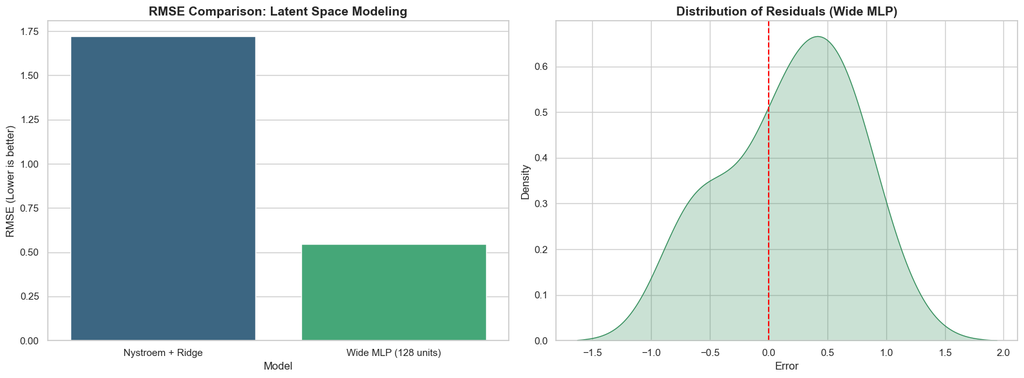

```python
results_df = pd.DataFrame(results)

fig, axes = plt.subplots(1, 2, figsize=(16, 6))

# Bar chart of RMSE
sns.barplot(data=results_df, x='Model', y='RMSE', palette='viridis', ax=axes[0])
axes[0].set_title('RMSE Comparison: Latent Space Modeling', fontsize=14, fontweight='bold')
axes[0].set_ylabel('RMSE (Lower is better)')

# Distribution of Residuals for the Wide MLP
residuals_mlp = y_test - y_pred_mlp
sns.kdeplot(residuals_mlp, fill=True, color='seagreen', ax=axes[1])
axes[1].axvline(0, color='red', linestyle='--')
axes[1].set_title('Distribution of Residuals (Wide MLP)', fontsize=14, fontweight='bold')
axes[1].set_xlabel('Error')

plt.tight_layout()
plt.savefig('latent_space_results.png')
print("\nPlots saved to latent_space_results.png")

# --- Export Latent Space Embeddings ---
# We extract the 128-dimensional hidden layer outputs for the entire dataset
X_all_scaled = scaler.transform(X)
# Manual computation of the ReLU hidden layer: (X * W) + b
hidden_layer_input = np.dot(X_all_scaled, mlp_model.coefs_[0]) + mlp_model.intercepts_[0]
embeddings = np.maximum(hidden_layer_input, 0)  # ReLU Activation

# Create a DataFrame for the 128D embeddings
embedding_cols = [f'latent_{i}' for i in range(embeddings.shape[1])]
embeddings_df = pd.DataFrame(embeddings, columns=embedding_cols)

# Add the target Concentration column for context/labeling
embeddings_df['Concentration'] = y.values

# Save to CSV using absolute path
embeddings_csv_path = r'c:\Users\mgpsk\Documents\voc-streamlit\latent_space_embeddings.csv'
embeddings_df.to_csv(embeddings_csv_path, index=False)
print(f"\nLatent space embeddings (128D) successfully saved to: {embeddings_csv_path}")

plt.show()
```